# Regression Residuals

Dr. B

Saturday, September 27, 2014

```r
data(mtcars)
str(mtcars)
```

```
## 'data.frame':    32 obs. of  11 variables:
##  $ mpg : num  21 21 22.8 21.4 18.7 18.1 14.3 24.4 22.8 19.2 ...
##  $ cyl : num  6 6 4 6 8 6 8 4 4 6 ...
##  $ disp: num  160 160 108 258 360 ...
##  $ hp  : num  110 110 93 110 175 105 245 62 95 123 ...
##  $ drat: num  3.9 3.9 3.85 3.08 3.15 2.76 3.21 3.69 3.92 3.92 ...
##  $ wt  : num  2.62 2.88 2.32 3.21 3.44 ...
##  $ qsec: num  16.5 17 18.6 19.4 17 ...
##  $ vs  : num  0 0 1 1 0 1 0 1 1 1 ...
##  $ am  : num  1 1 1 0 0 0 0 0 0 0 ...
##  $ gear: num  4 4 4 3 3 3 3 4 4 4 ...
##  $ carb: num  4 4 1 1 2 1 4 2 2 4 ...
```

For more efficient analysis, I transformed transforming the following 5 variables into factors:

```r
mtcars$gear <- factor(mtcars$gear,levels=c(3,4,5),labels=c("3gears","4gears","5gears"))
mtcars$cyl <- factor(mtcars$cyl,levels=c(4,6,8),labels=c("4cyl","6cyl","8cyl"))
mtcars$am <- factor(mtcars$am,levels=c(0,1),labels=c("Automatic","Manual"))
mtcars$vs <- factor(mtcars$vs)
mtcars$carb <- factor(mtcars$carb)
```

## Definitions

Residual: The difference between the predicted value (based on the regression equation) and the actual, observed value.

Outlier: In linear regression, an outlier is an observation with large residual. In other words, it is an observation whose dependent-variable value is unusual given its value on the predictor variables. An outlier may indicate a sample peculiarity or may indicate a data entry error or other problem.

Leverage: An observation with an extreme value on a predictor variable is a point with high leverage. Leverage is a measure of how far an independent variable deviates from its mean. High leverage points can have a great amount of effect on the estimate of regression coefficients.

Influence: An observation is said to be influential if removing the observation substantially changes the estimate of the regression coefficients. Influence can be thought of as the product of leverage and outlierness.

Cook’s distance (or Cook’s D): A measure that combines the information of leverage and residual of the observation.

Performed stepwise model selection in order to select significant predictors for the final, best model. The step function will perform this selection by calling lm repeatedly to build multiple regression models and select the best variables from them using both forward selection and backward elimination methods using AIC algorithm. This ensures that the useful variables are included in the model while omitting ones that do not contribute significantly to predicting mpg.

```r
bestmodel <- step(lm(mpg ~ ., data = mtcars), direction = "both")
```

```
## Start:  AIC=76.4
## mpg ~ cyl + disp + hp + drat + wt + qsec + vs + am + gear + carb
##
##        Df Sum of Sq RSS  AIC
## - carb  5     13.60 134 69.8
## - gear  2      3.97 124 73.4
## - am    1      1.14 122 74.7
## - qsec  1      1.24 122 74.7
## - drat  1      1.82 122 74.9
## - cyl   2     10.93 131 75.2
## - vs    1      3.63 124 75.4
## <none>              120 76.4
## - disp  1      9.97 130 76.9
## - wt    1     25.55 146 80.6
## - hp    1     25.67 146 80.6
##
## Step:  AIC=69.83
## mpg ~ cyl + disp + hp + drat + wt + qsec + vs + am + gear
##
##        Df Sum of Sq RSS  AIC
## - gear  2      5.02 139 67.0
## - disp  1      0.99 135 68.1
## - drat  1      1.19 135 68.1
## - vs    1      3.68 138 68.7
## - cyl   2     12.56 147 68.7
## - qsec  1      5.26 139 69.1
## <none>              134 69.8
## - am    1     11.93 146 70.6
## - wt    1     19.80 154 72.2
## - hp    1     22.79 157 72.9
## + carb  5     13.60 120 76.4
##
## Step:  AIC=67
## mpg ~ cyl + disp + hp + drat + wt + qsec + vs + am
##
##        Df Sum of Sq RSS  AIC
## - drat  1      0.97 140 65.2
## - cyl   2     10.42 149 65.3
## - disp  1      1.55 141 65.4
## - vs    1      2.18 141 65.5
```

[output cut: 56 more lines]

```
## Step:  AIC=61.65
## mpg ~ cyl + hp + wt + am
##
##        Df Sum of Sq RSS  AIC
## <none>              151 61.7
## - am    1       9.8 161 61.7
## + vs    1       7.3 144 62.1
## + qsec  1       7.0 144 62.1
## - cyl   2      29.3 180 63.3
## + disp  1       0.6 150 63.5
## + drat  1       0.2 151 63.6
## + gear  2       1.4 150 65.4
## - hp    1      31.9 183 65.8
## - wt    1      46.2 197 68.2
## + carb  5       5.6 145 70.4
```

```r
summary(bestmodel)
```

```
##
## Call:
## lm(formula = mpg ~ cyl + hp + wt + am, data = mtcars)
##
## Residuals:
##    Min     1Q Median     3Q    Max
## -3.939 -1.256 -0.401  1.125  5.051
##
## Coefficients:
##             Estimate Std. Error t value Pr(>|t|)
## (Intercept)  33.7083     2.6049   12.94  7.7e-13 ***
## cyl6cyl      -3.0313     1.4073   -2.15   0.0407 *
## cyl8cyl      -2.1637     2.2843   -0.95   0.3523
## hp           -0.0321     0.0137   -2.35   0.0269 *
## wt           -2.4968     0.8856   -2.82   0.0091 **
## amManual      1.8092     1.3963    1.30   0.2065
## ---
## Signif. codes:  0 '***' 0.001 '**' 0.01 '*' 0.05 '.' 0.1 ' ' 1
##
## Residual standard error: 2.41 on 26 degrees of freedom
## Multiple R-squared:  0.866,  Adjusted R-squared:  0.84
## F-statistic: 33.6 on 5 and 26 DF,  p-value: 1.51e-10
```

```r
residuals(bestmodel) # residuals
```

```
##           Mazda RX4       Mazda RX4 Wag          Datsun 710
##           -1.412460           -0.775769           -3.938714
##      Hornet 4 Drive   Hornet Sportabout             Valiant
##            2.282364            1.363595           -0.566459
##          Duster 360           Merc 240D            Merc 230
##           -0.464157            0.647347            0.007085
##            Merc 280           Merc 280C          Merc 450SE
##            1.061574           -0.338426            0.797145
##          Merc 450SL         Merc 450SLC  Cadillac Fleetwood
##            0.848223           -1.126936           -1.453861
## Lincoln Continental   Chrysler Imperial            Fiat 128
##           -0.698318            3.886074            4.494712
##         Honda Civic      Toyota Corolla       Toyota Corona
##            0.584535            5.051260           -2.939025
##    Dodge Challenger         AMC Javelin          Camaro Z28
##           -2.439395           -2.951625           -0.790013
##    Pontiac Firebird           Fiat X1-9       Porsche 914-2
##            2.874811           -1.266948           -1.252362
##        Lotus Europa      Ford Pantera L        Ferrari Dino
##            2.288533           -1.162021           -0.250823
##       Maserati Bora          Volvo 142E
##            1.316480           -3.676422
```

## Assessing Outliers

```r
require(car)
outlierTest(bestmodel) # Bonferonni p-value for most extreme obs
```

```
##
## No Studentized residuals with Bonferonni p < 0.05
## Largest |rstudent|:
##                rstudent unadjusted p-value Bonferonni p
## Toyota Corolla    2.451             0.0216       0.6913
```

## Model Residuals and Diagnostics

In this section, I have prepared the residual plots (Appendix - Figure 3) of the regression model along with computation of regression diagnostics for the linear model. This analysis was comepleted in order to examine the residuals and identify leverage points.

```r
residuals(bestmodel) # residuals
```

```
##           Mazda RX4       Mazda RX4 Wag          Datsun 710
##           -1.412460           -0.775769           -3.938714
##      Hornet 4 Drive   Hornet Sportabout             Valiant
##            2.282364            1.363595           -0.566459
##          Duster 360           Merc 240D            Merc 230
##           -0.464157            0.647347            0.007085
##            Merc 280           Merc 280C          Merc 450SE
##            1.061574           -0.338426            0.797145
##          Merc 450SL         Merc 450SLC  Cadillac Fleetwood
##            0.848223           -1.126936           -1.453861
## Lincoln Continental   Chrysler Imperial            Fiat 128
##           -0.698318            3.886074            4.494712
##         Honda Civic      Toyota Corolla       Toyota Corona
##            0.584535            5.051260           -2.939025
##    Dodge Challenger         AMC Javelin          Camaro Z28
##           -2.439395           -2.951625           -0.790013
##    Pontiac Firebird           Fiat X1-9       Porsche 914-2
##            2.874811           -1.266948           -1.252362
##        Lotus Europa      Ford Pantera L        Ferrari Dino
##            2.288533           -1.162021           -0.250823
##       Maserati Bora          Volvo 142E
##            1.316480           -3.676422
```

Normality of Residuals

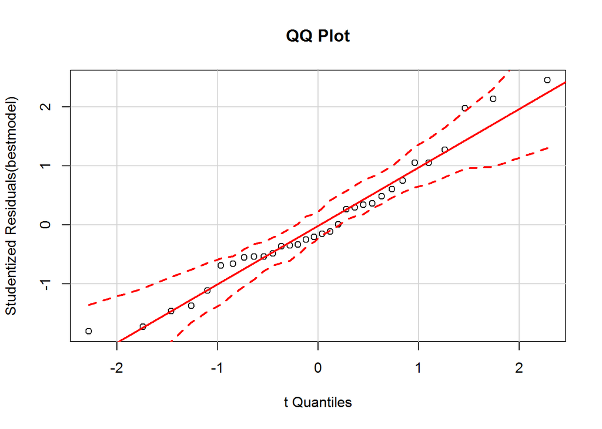

```r
# qq plot for studentized resid
qqPlot(bestmodel, main="QQ Plot")
```

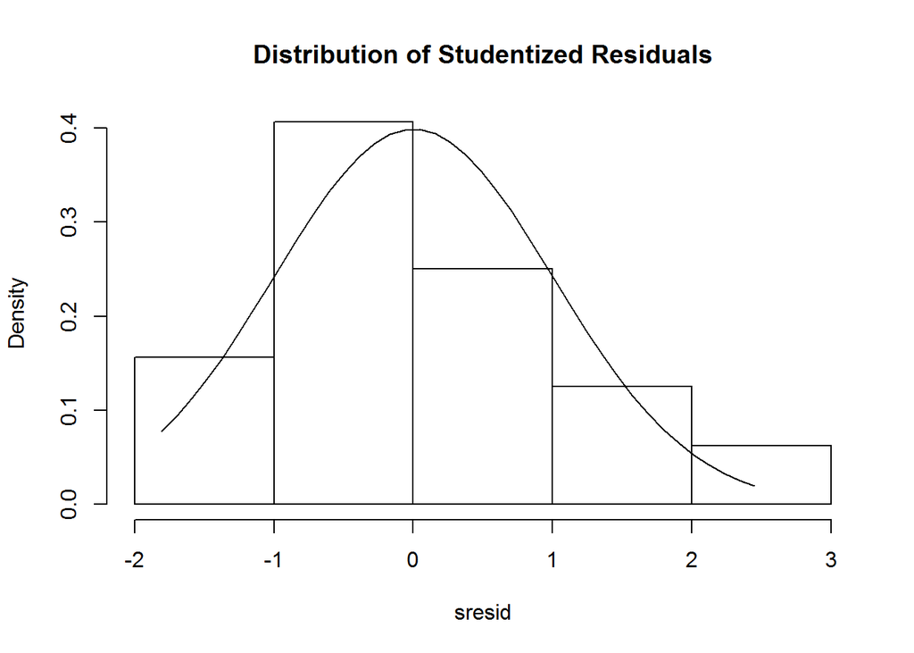

```r
# distribution of studentized residuals
library(MASS)
sresid <- studres(bestmodel)
hist(sresid, freq=FALSE,
   main="Distribution of Studentized Residuals")
xfit<-seq(min(sresid),max(sresid),length=40)
yfit<-dnorm(xfit)
lines(xfit, yfit)
```

Evaluate homoscedasticity

```r
# non-constant error variance test
ncvTest(bestmodel)
```

```
## Non-constant Variance Score Test
## Variance formula: ~ fitted.values
## Chisquare = 3.693    Df = 1     p = 0.05463
```

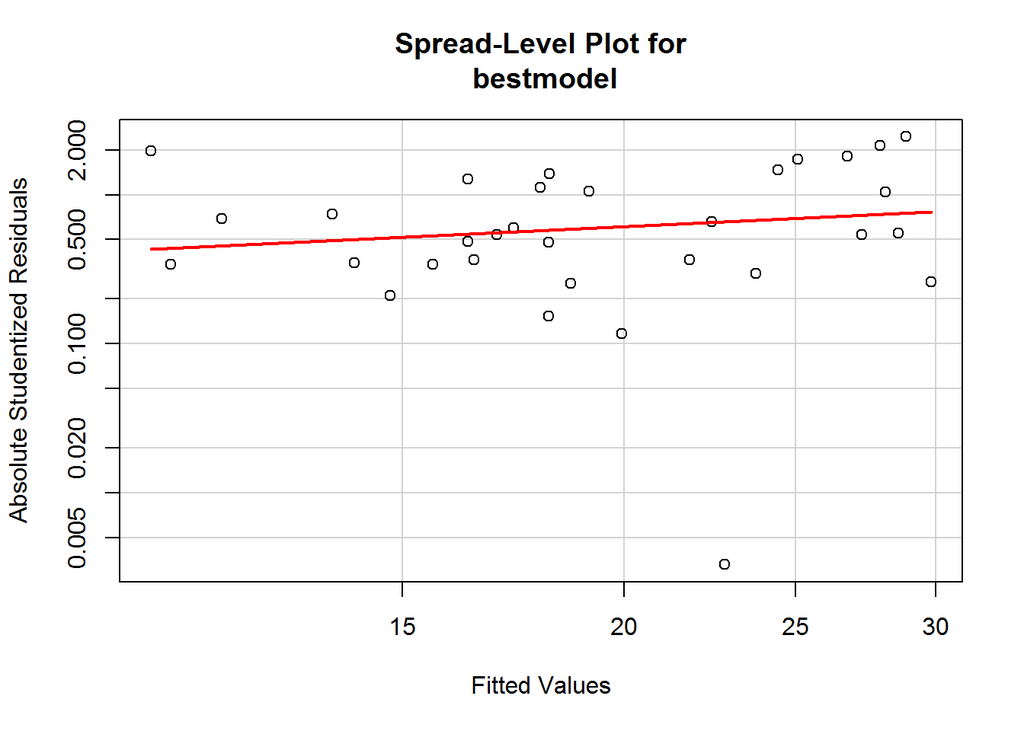

```
##
## Suggested power transformation:  0.4246
```

```r
# plot studentized residuals vs. fitted values
spreadLevelPlot(bestmodel)
```

Evaluate Collinearity

```r
vif(bestmodel) # variance inflation factors
```

```
##      GVIF Df GVIF^(1/(2*Df))
## cyl 5.825  2           1.554
## hp  4.704  1           2.169
## wt  4.007  1           2.002
## am  2.591  1           1.610
```

```r
sqrt(vif(bestmodel)) > 2 # problem?
```

```
##      GVIF    Df GVIF^(1/(2*Df))
## cyl  TRUE FALSE           FALSE
## hp   TRUE FALSE           FALSE
## wt   TRUE FALSE           FALSE
## am  FALSE FALSE           FALSE
```

Evaluate Nonlinearity

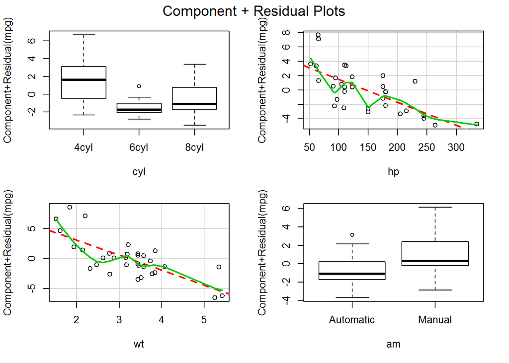

```r
# component + residual plot
crPlots(bestmodel)
```

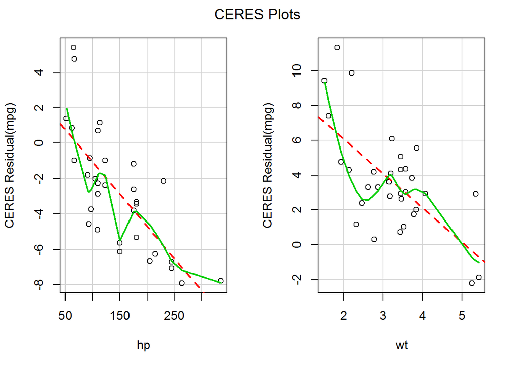

```r
# Ceres plots
ceresPlots(bestmodel)
```

Test for Autocorrelated Errors

```r
durbinWatsonTest(bestmodel)
```

```
##  lag Autocorrelation D-W Statistic p-value
##    1         0.04422         1.809    0.28
##  Alternative hypothesis: rho != 0
```

An analaysis of the residual plots indicated:

1. The points in the Residuals vs. Fitted plot are randomly scattered on the plot, which verifies the condition of independence.
2. The Normal Q-Q plot consists of the points which mostly fall on the line, which indicates that the residuals are normally distributed.
3. The Scale-Location plot consists of points scattered in a constant band pattern, which indicates constant variance.
4. There were some distinct points of interest (outliers or leverage points) in the top right of the plots that may indicate values of increased leverage of outliers.

I computed regression diagnostics of the best model to identify leverage points. I computed the top three points in each case of influence measures. The data points with the most leverage in the fit are identfied by hatvalues().

```r
leverage <- hatvalues(bestmodel)
tail(sort(leverage),3)
```

```
##       Toyota Corona Lincoln Continental       Maserati Bora
##              0.2778              0.2937              0.4714
```

The data points that influence the model coefficients the most are given by the dfbetas() function.

```r
influential <- dfbetas(bestmodel)
tail(sort(influential[,6]),3)
```

```
## Chrysler Imperial          Fiat 128     Toyota Corona
##            0.3507            0.4292            0.7305
```

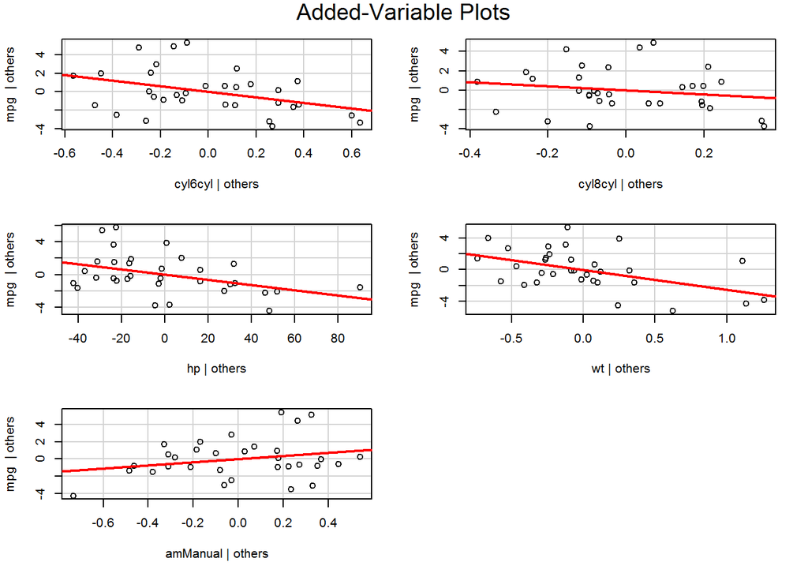

```r
# Influential Observations
# added variable plots
avPlots(bestmodel)
```

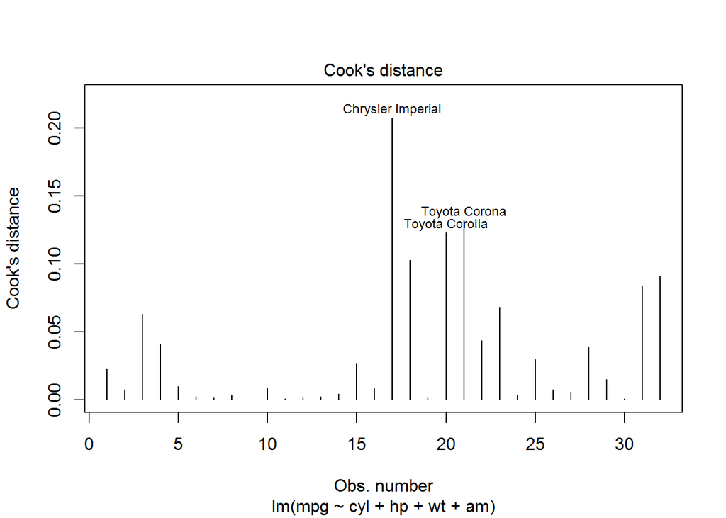

```r
# Cook's D plot
# identify D values > 4/(n-k-1)
cutoff <- 4/((nrow(mtcars)-length(bestmodel$coefficients)-2))
plot(bestmodel, which=4, cook.levels=cutoff)
```

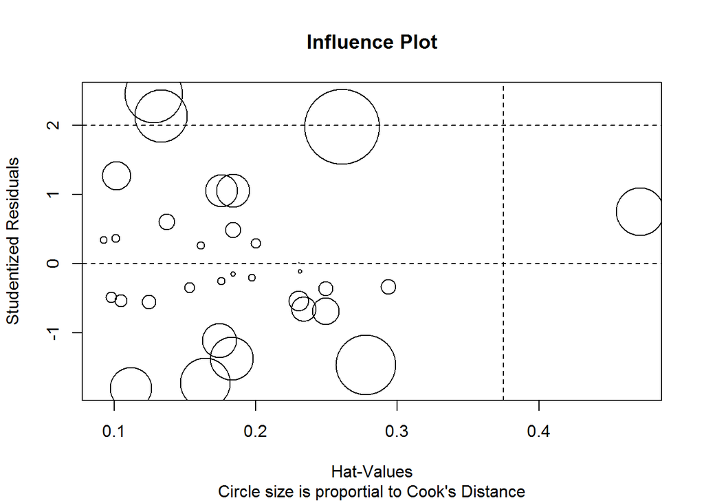

```r
# Influence Plot
influencePlot(bestmodel,id.method="identify", main="Influence Plot", sub="Circle size is proportial to Cook's Distance" )
```

## Residual Plots

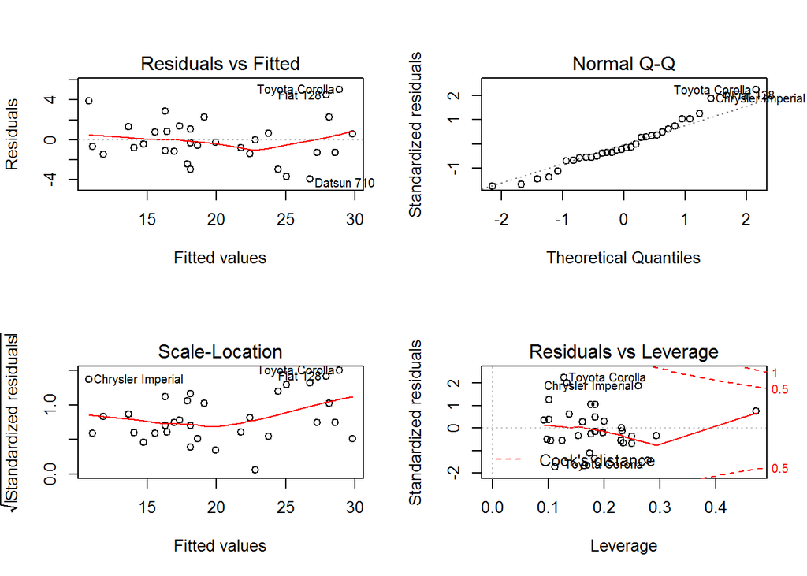

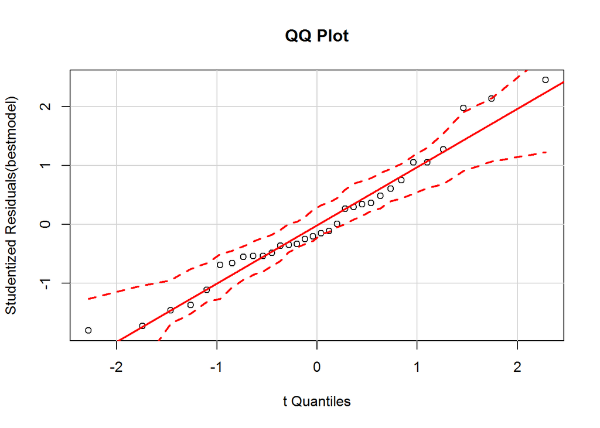

[figure not shown]

Global test of model assumptions

```r
require(gvlma)
gvmodel <- gvlma(bestmodel)
summary(gvmodel)
```

```
##
## Call:
## lm(formula = mpg ~ cyl + hp + wt + am, data = mtcars)
##
## Residuals:
##    Min     1Q Median     3Q    Max
## -3.939 -1.256 -0.401  1.125  5.051
##
## Coefficients:
##             Estimate Std. Error t value Pr(>|t|)
## (Intercept)  33.7083     2.6049   12.94  7.7e-13 ***
## cyl6cyl      -3.0313     1.4073   -2.15   0.0407 *
## cyl8cyl      -2.1637     2.2843   -0.95   0.3523
## hp           -0.0321     0.0137   -2.35   0.0269 *
## wt           -2.4968     0.8856   -2.82   0.0091 **
## amManual      1.8092     1.3963    1.30   0.2065
## ---
## Signif. codes:  0 '***' 0.001 '**' 0.01 '*' 0.05 '.' 0.1 ' ' 1
##
## Residual standard error: 2.41 on 26 degrees of freedom
## Multiple R-squared:  0.866,  Adjusted R-squared:  0.84
## F-statistic: 33.6 on 5 and 26 DF,  p-value: 1.51e-10
##
##
## ASSESSMENT OF THE LINEAR MODEL ASSUMPTIONS
## USING THE GLOBAL TEST ON 4 DEGREES-OF-FREEDOM:
## Level of Significance =  0.05
##
## Call:
##  gvlma(x = bestmodel)
##
##                     Value p-value                   Decision
## Global Stat        7.9055  0.0951    Assumptions acceptable.
## Skewness           1.0085  0.3153    Assumptions acceptable.
## Kurtosis           0.0222  0.8816    Assumptions acceptable.
## Link Function      6.0790  0.0137 Assumptions NOT satisfied!
## Heteroscedasticity 0.7958  0.3723    Assumptions acceptable.
```